# Python for Earth System Sciences

#### Remon Sadikni, Alexander Winkler

#### May 25th, 2018

## Pandas - an Introduction

#### *Easy-to-use Data Structures and Data Analysis Tool*

[figure not shown]

### Overview

- Labeled array data structures (**Series** and **DataFrame**)
- Simple axis **label-based indexing** and multi-level / hierarchical axis indexing
- Integrated engine for aggregating and transforming data sets, e.g. **groupby** method
- **Timestamp generation** and custom date offsets enabling the implementation of customized frequencies
- **Input/Output tools**: loading tabular data from all sort of file formats (CSV, delimited, Excel 2003, etc.)
- Comprehensive **statistics toolbox** (rolling mean, rolling standard deviation, etc.)

Source of this introduction: [Pandas Documentation](http://pandas.pydata.org/pandas-docs/stable/index.html) and [Enthought Cheat Sheet](https://www.enthought.com/cheat-sheets-pandas-python-for-data-analysis).

### Getting started

```python
# Import standard packages
import matplotlib.pyplot as plt
import numpy as np

# Pandas is conventionally imported as 'pd'
import pandas as pd
```

### Data structures

| Dimensions | Name | Description |
| --- | --- | --- |
| 1 | **Series** | 1D labeled homogeneously-typed array |
| 2 | **DataFrame** | General 2D labeled, size-mutable tabular structure with potentially heterogeneously-typed columns |
| 3 | Panel | General 3D labeled, also size-mutable array |

#### Why more than one data structure?

> "The best way to think about the pandas data structures is as flexible containers for lower dimensional data. For example, **DataFrame is a container for Series, and Panel is a container for DataFrame objects**. We would like to be able to insert and remove objects from these containers in a dictionary-like fashion."

### Series

[figure not shown]

1D labeled series attached to an index.

Example: Create 1D Series object with random sample data, letting pandas create a default integer index

```python
data = np.random.rand(10) # 10 random numbers

# Create series object
s = pd.Series(
    data=data
)

print s
```

```
0    0.024954
1    0.316463
2    0.685920
3    0.996129
4    0.359553
5    0.748827
6    0.151202
7    0.880696
8    0.255135
9    0.396014
dtype: float64
```

Create Series object including labeled index:

```python
s = pd.Series(
    data=data,
    index=['a','b','c','d','e','f','g','h','i','j'], # include index
)

print s
```

```
a    0.024954
b    0.316463
c    0.685920
d    0.996129
e    0.359553
f    0.748827
g    0.151202
h    0.880696
i    0.255135
j    0.396014
dtype: float64
```

### DatetimeIndex

Using `pd.date_range()` method based on `datetime` module, we can easily set up a customized DatetimeIndex and convert the Series object to a time series:

```python
# Create datetimeindex; specify frequency, start, periods, or end arguments
dt_index = pd.date_range(start='2000-01-01',
                         freq='D',
                         periods=10)

s = pd.Series(
    data=data,
    index=dt_index,
)

print s
```

```
2000-01-01    0.024954
2000-01-02    0.316463
2000-01-03    0.685920
2000-01-04    0.996129
2000-01-05    0.359553
2000-01-06    0.748827
2000-01-07    0.151202
2000-01-08    0.880696
2000-01-09    0.255135
2000-01-10    0.396014
Freq: D, dtype: float64
```

```python
# Check the index
print s.index
```

```
DatetimeIndex(['2000-01-01', '2000-01-02', '2000-01-03', '2000-01-04',
               '2000-01-05', '2000-01-06', '2000-01-07', '2000-01-08',
               '2000-01-09', '2000-01-10'],
              dtype='datetime64[ns]', freq='D')
```

[Here](http://pandas.pydata.org/pandas-docs/stable/timeseries.html#offset-aliases) you find an overview of the Pandas frequency strings, e.g. 'D' for *calendar day frequency*.

### DataFrame

[figure not shown]

2D-labeled data arranged in **Rows** (or Index, Axis=0) and **Columns** (Axis=1).

Create 2D DataFrame object with random sample data with a datetime index and labeled columns:

```python
# Random sample data
data = np.random.rand(12,5)

# DatetimeIndex
index = pd.date_range(start='2000', end='2001', freq='M')

# Create DataFrame object
df = pd.DataFrame(data=data,
                  index=index,
                  columns=['A','B','C','D','E'], # specify column names
                 )
```

```python
df
```

|  | A | B | C | D | E |
| --- | --- | --- | --- | --- | --- |
| 2000-01-31 | 0.687233 | 0.302154 | 0.186104 | 0.708635 | 0.854492 |
| 2000-02-29 | 0.534118 | 0.029473 | 0.667316 | 0.426997 | 0.492036 |
| 2000-03-31 | 0.952695 | 0.174465 | 0.743483 | 0.666755 | 0.566801 |
| 2000-04-30 | 0.499666 | 0.612822 | 0.233911 | 0.653217 | 0.166598 |
| 2000-05-31 | 0.670118 | 0.488098 | 0.737827 | 0.926091 | 0.864640 |
| 2000-06-30 | 0.904326 | 0.284064 | 0.703385 | 0.263958 | 0.221536 |
| 2000-07-31 | 0.516943 | 0.584471 | 0.567301 | 0.865683 | 0.252062 |
| 2000-08-31 | 0.569492 | 0.548232 | 0.788223 | 0.834757 | 0.666635 |
| 2000-09-30 | 0.879040 | 0.582043 | 0.226310 | 0.821906 | 0.321971 |
| 2000-10-31 | 0.222359 | 0.838564 | 0.216241 | 0.003979 | 0.016282 |
| 2000-11-30 | 0.340368 | 0.819150 | 0.955170 | 0.024868 | 0.420327 |
| 2000-12-31 | 0.692878 | 0.684881 | 0.384275 | 0.265439 | 0.913044 |

#### DataFrame columns can contain data of different types.

Create DataFrame providing a dictionary containing data of different types (`dtypes`):

```python
data = {'A': np.random.randint(100, size=5), # 5 random integers between 0 and 100
        'B': 1., # float
        'C': ['car', 'plane', 'bus', 'bike', 'train'], # strings
        'D': pd.Timestamp('20130102'), # Timestamp
}

# pd.DataFrame interprets provided dictionary of objects
df = pd.DataFrame(data)
```

```python
df
```

|  | A | B | C | D |
| --- | --- | --- | --- | --- |
| 0 | 55 | 1.0 | car | 2013-01-02 |
| 1 | 91 | 1.0 | plane | 2013-01-02 |
| 2 | 12 | 1.0 | bus | 2013-01-02 |
| 3 | 15 | 1.0 | bike | 2013-01-02 |
| 4 | 3 | 1.0 | train | 2013-01-02 |

Check `dtype` of each column:

```python
print df.dtypes
```

```
A             int64
B           float64
C            object
D    datetime64[ns]
dtype: object
```

### Viewing the Data

View the top and bottom rows of the DataFrame:

```python
# Set up monthly random sample data
data = np.random.rand(12,5)
index = pd.date_range(start='2000', end='2001', freq='M')

df = pd.DataFrame(data=data,
                  index=index,
                  columns=['A','B','C','D','E'],
                 )
```

```python
df.head() # display first 5 (default) rows / months
```

|  | A | B | C | D | E |
| --- | --- | --- | --- | --- | --- |
| 2000-01-31 | 0.827491 | 0.612359 | 0.822154 | 0.220368 | 0.859666 |
| 2000-02-29 | 0.212386 | 0.138290 | 0.938185 | 0.207394 | 0.498849 |
| 2000-03-31 | 0.536212 | 0.475255 | 0.223957 | 0.925290 | 0.861178 |
| 2000-04-30 | 0.256930 | 0.157361 | 0.180372 | 0.997725 | 0.514299 |
| 2000-05-31 | 0.898754 | 0.717829 | 0.551792 | 0.915755 | 0.730949 |

```python
df.tail(3) # display last 3 rows / months
```

|  | A | B | C | D | E |
| --- | --- | --- | --- | --- | --- |
| 2000-10-31 | 0.536303 | 0.850475 | 0.982421 | 0.889788 | 0.024092 |
| 2000-11-30 | 0.211561 | 0.751511 | 0.018309 | 0.344407 | 0.632735 |
| 2000-12-31 | 0.505215 | 0.618922 | 0.180498 | 0.814176 | 0.615381 |

View key elements of DataFrame: Index, columns, and values:

```python
df.index # display index of the DataFrame
```

```
DatetimeIndex(['2000-01-31', '2000-02-29', '2000-03-31', '2000-04-30',
               '2000-05-31', '2000-06-30', '2000-07-31', '2000-08-31',
               '2000-09-30', '2000-10-31', '2000-11-30', '2000-12-31'],
              dtype='datetime64[ns]', freq='M')
```

```python
df.columns # display columns of the DataFrame
```

```
Index([u'A', u'B', u'C', u'D', u'E'], dtype='object')
```

```python
df.values # display all data of the DataFrame
```

```
array([[0.82749086, 0.61235925, 0.82215394, 0.22036838, 0.85966598],
       [0.21238589, 0.13828981, 0.93818526, 0.20739438, 0.49884896],
       [0.53621172, 0.4752554 , 0.22395731, 0.92528978, 0.86117797],
       [0.25693043, 0.15736115, 0.18037245, 0.99772518, 0.51429942],
       [0.89875406, 0.71782945, 0.55179214, 0.9157549 , 0.7309492 ],
       [0.38945754, 0.00354873, 0.41230672, 0.7199843 , 0.80022012],
       [0.05408474, 0.77499787, 0.52995341, 0.09338743, 0.13993294],
       [0.23001462, 0.32866379, 0.01729302, 0.97211264, 0.5716674 ],
       [0.99151139, 0.09284221, 0.64365762, 0.88288925, 0.9074224 ],
       [0.53630292, 0.85047534, 0.9824215 , 0.88978767, 0.02409166],
       [0.21156078, 0.75151068, 0.01830931, 0.34440747, 0.63273481],
       [0.50521507, 0.61892178, 0.1804979 , 0.81417617, 0.61538127]])
```

```python
df['B'].values # display data of column 'B'
```

```
array([0.61235925, 0.13828981, 0.4752554 , 0.15736115, 0.71782945,
       0.00354873, 0.77499787, 0.32866379, 0.09284221, 0.85047534,
       0.75151068, 0.61892178])
```

Show a quick descriptive statistic summary of the data:

```python
df.describe()
```

|  | A | B | C | D | E |
| --- | --- | --- | --- | --- | --- |
| count | 12.000000 | 12.000000 | 12.000000 | 12.000000 | 12.000000 |
| mean | 0.470827 | 0.460171 | 0.458408 | 0.665273 | 0.596366 |
| std | 0.302901 | 0.302616 | 0.341806 | 0.343188 | 0.278020 |
| min | 0.054085 | 0.003549 | 0.017293 | 0.093387 | 0.024092 |
| 25% | 0.225607 | 0.152593 | 0.180467 | 0.313398 | 0.510437 |
| 50% | 0.447336 | 0.543807 | 0.471130 | 0.848533 | 0.624058 |
| 75% | 0.609100 | 0.726250 | 0.688282 | 0.918139 | 0.815082 |
| max | 0.991511 | 0.850475 | 0.982421 | 0.997725 | 0.907422 |

Transpose the data and call `.describe()` method:

```python
df.transpose().describe() # or df.T.describe()
```

|  | 2000-01-31 00:00:00 | 2000-02-29 00:00:00 | 2000-03-31 00:00:00 | 2000-04-30 00:00:00 | 2000-05-31 00:00:00 | 2000-06-30 00:00:00 | 2000-07-31 00:00:00 | 2000-08-31 00:00:00 | 2000-09-30 00:00:00 | 2000-10-31 00:00:00 | 2000-11-30 00:00:00 | 2000-12-31 00:00:00 |
| --- | --- | --- | --- | --- | --- | --- | --- | --- | --- | --- | --- | --- |
| count | 5.000000 | 5.000000 | 5.000000 | 5.000000 | 5.000000 | 5.000000 | 5.000000 | 5.000000 | 5.000000 | 5.000000 | 5.000000 | 5.000000 |
| mean | 0.668408 | 0.399021 | 0.604378 | 0.421338 | 0.763016 | 0.465103 | 0.318471 | 0.423950 | 0.703665 | 0.656616 | 0.391705 | 0.546838 |
| std | 0.268982 | 0.331737 | 0.289383 | 0.352009 | 0.149532 | 0.315757 | 0.318426 | 0.365501 | 0.365102 | 0.391364 | 0.300695 | 0.233078 |
| min | 0.220368 | 0.138290 | 0.223957 | 0.157361 | 0.551792 | 0.003549 | 0.054085 | 0.017293 | 0.092842 | 0.024092 | 0.018309 | 0.180498 |
| 25% | 0.612359 | 0.207394 | 0.475255 | 0.180372 | 0.717829 | 0.389458 | 0.093387 | 0.230015 | 0.643658 | 0.536303 | 0.211561 | 0.505215 |
| 50% | 0.822154 | 0.212386 | 0.536212 | 0.256930 | 0.730949 | 0.412307 | 0.139933 | 0.328664 | 0.882889 | 0.850475 | 0.344407 | 0.615381 |
| 75% | 0.827491 | 0.498849 | 0.861178 | 0.514299 | 0.898754 | 0.719984 | 0.529953 | 0.571667 | 0.907422 | 0.889788 | 0.632735 | 0.618922 |
| max | 0.859666 | 0.938185 | 0.925290 | 0.997725 | 0.915755 | 0.800220 | 0.774998 | 0.972113 | 0.991511 | 0.982421 | 0.751511 | 0.814176 |

Sorting data by axis or values:

```python
# Reverse order (ascending=False) of index (axis=0)
df.sort_index(axis=0, ascending=False)
```

|  | A | B | C | D | E |
| --- | --- | --- | --- | --- | --- |
| 2000-12-31 | 0.505215 | 0.618922 | 0.180498 | 0.814176 | 0.615381 |
| 2000-11-30 | 0.211561 | 0.751511 | 0.018309 | 0.344407 | 0.632735 |
| 2000-10-31 | 0.536303 | 0.850475 | 0.982421 | 0.889788 | 0.024092 |
| 2000-09-30 | 0.991511 | 0.092842 | 0.643658 | 0.882889 | 0.907422 |
| 2000-08-31 | 0.230015 | 0.328664 | 0.017293 | 0.972113 | 0.571667 |
| 2000-07-31 | 0.054085 | 0.774998 | 0.529953 | 0.093387 | 0.139933 |
| 2000-06-30 | 0.389458 | 0.003549 | 0.412307 | 0.719984 | 0.800220 |
| 2000-05-31 | 0.898754 | 0.717829 | 0.551792 | 0.915755 | 0.730949 |
| 2000-04-30 | 0.256930 | 0.157361 | 0.180372 | 0.997725 | 0.514299 |
| 2000-03-31 | 0.536212 | 0.475255 | 0.223957 | 0.925290 | 0.861178 |
| 2000-02-29 | 0.212386 | 0.138290 | 0.938185 | 0.207394 | 0.498849 |
| 2000-01-31 | 0.827491 | 0.612359 | 0.822154 | 0.220368 | 0.859666 |

```python
# Reverse order alphabetically (ascending=False) of columns (axis=1)
df.sort_index(axis=1, ascending=False)
```

|  | E | D | C | B | A |
| --- | --- | --- | --- | --- | --- |
| 2000-01-31 | 0.859666 | 0.220368 | 0.822154 | 0.612359 | 0.827491 |
| 2000-02-29 | 0.498849 | 0.207394 | 0.938185 | 0.138290 | 0.212386 |
| 2000-03-31 | 0.861178 | 0.925290 | 0.223957 | 0.475255 | 0.536212 |
| 2000-04-30 | 0.514299 | 0.997725 | 0.180372 | 0.157361 | 0.256930 |
| 2000-05-31 | 0.730949 | 0.915755 | 0.551792 | 0.717829 | 0.898754 |
| 2000-06-30 | 0.800220 | 0.719984 | 0.412307 | 0.003549 | 0.389458 |
| 2000-07-31 | 0.139933 | 0.093387 | 0.529953 | 0.774998 | 0.054085 |
| 2000-08-31 | 0.571667 | 0.972113 | 0.017293 | 0.328664 | 0.230015 |
| 2000-09-30 | 0.907422 | 0.882889 | 0.643658 | 0.092842 | 0.991511 |
| 2000-10-31 | 0.024092 | 0.889788 | 0.982421 | 0.850475 | 0.536303 |
| 2000-11-30 | 0.632735 | 0.344407 | 0.018309 | 0.751511 | 0.211561 |
| 2000-12-31 | 0.615381 | 0.814176 | 0.180498 | 0.618922 | 0.505215 |

```python
# Sort DataFrame depending on values of column 'D'
df.sort_values(by='D')
```

|  | A | B | C | D | E |
| --- | --- | --- | --- | --- | --- |
| 2000-07-31 | 0.054085 | 0.774998 | 0.529953 | 0.093387 | 0.139933 |
| 2000-02-29 | 0.212386 | 0.138290 | 0.938185 | 0.207394 | 0.498849 |
| 2000-01-31 | 0.827491 | 0.612359 | 0.822154 | 0.220368 | 0.859666 |
| 2000-11-30 | 0.211561 | 0.751511 | 0.018309 | 0.344407 | 0.632735 |
| 2000-06-30 | 0.389458 | 0.003549 | 0.412307 | 0.719984 | 0.800220 |
| 2000-12-31 | 0.505215 | 0.618922 | 0.180498 | 0.814176 | 0.615381 |
| 2000-09-30 | 0.991511 | 0.092842 | 0.643658 | 0.882889 | 0.907422 |
| 2000-10-31 | 0.536303 | 0.850475 | 0.982421 | 0.889788 | 0.024092 |
| 2000-05-31 | 0.898754 | 0.717829 | 0.551792 | 0.915755 | 0.730949 |
| 2000-03-31 | 0.536212 | 0.475255 | 0.223957 | 0.925290 | 0.861178 |
| 2000-08-31 | 0.230015 | 0.328664 | 0.017293 | 0.972113 | 0.571667 |
| 2000-04-30 | 0.256930 | 0.157361 | 0.180372 | 0.997725 | 0.514299 |

### *Reminder*: Explore the functionality interactively

In the interactive IPython console, tab completion for e.g. column names, public attributes, and methods is automatically enabled:

Just hit TAB in the IPython Console

```
df.<TAB>
```

Then, use the `help()` function to learn how to apply these methods, e.g.:

```python
help(df.sort_index) # or attach ? before statement: ?df.sort_index
```

```
Help on method sort_index in module pandas.core.frame:

sort_index(self, axis=0, level=None, ascending=True, inplace=False, kind='quicksort', na_position='last', sort_remaining=True, by=None) method of pandas.core.frame.DataFrame instance
    Sort object by labels (along an axis)

    Parameters
    ----------
    axis : index, columns to direct sorting
    level : int or level name or list of ints or list of level names
        if not None, sort on values in specified index level(s)
    ascending : boolean, default True
        Sort ascending vs. descending
    inplace : bool, default False
        if True, perform operation in-place
    kind : {'quicksort', 'mergesort', 'heapsort'}, default 'quicksort'
         Choice of sorting algorithm. See also ndarray.np.sort for more
         information.  `mergesort` is the only stable algorithm. For
         DataFrames, this option is only applied when sorting on a single
         column or label.
    na_position : {'first', 'last'}, default 'last'
         `first` puts NaNs at the beginning, `last` puts NaNs at the end.
         Not implemented for MultiIndex.
    sort_remaining : bool, default True
        if true and sorting by level and index is multilevel, sort by other
        levels too (in order) after sorting by specified level

    Returns
    -------
    sorted_obj : DataFrame
```

### Input / Output

Pandas provides comprehensive IO engines (`pd.read_*` and `pd.to_*`) for a wide range of data formats:

[figure not shown]

#### Example: DWD Station Fuhlsbüttel, Hamburg

Reading data from a **.csv file**:

```python
# Read data and explore structure
filename = 'Data/dwdstation_hamburg_fuhlsbuettel_kl_10147.csv'
df = pd.read_csv(filename)
```

Display the shape of the data:

```python
df.shape
```

```
(46527, 37)
```

Display columns (so, the header, if specified in the file):

```python
df.columns
```

```
Index([u'#Stations-Kennziffer', u' Stations-ID', u' Stationsname',
       u' Stationshoehe (m)', u' Geogr. Breite', u' Geogr. Laenge', u' Jahr',
       u' Monat', u' Tag',
       u' Tagesmittel des Luftdruckes in Stationshoehe (hPa)', u' Quality',
       u' Tagesmaximum der Temperatur der Luft in 2m Hoehe (grad C)',
       u' Quality.1',
       u' Tagesminimum der Temperatur der Luft in 2m Hoehe (grad C)',
       u' Quality.2',
       u' Tagesmittel der Temperatur der Luft in 2m Hoehe (grad C)',
       u' Quality.3', u' Tagesmittel des Dampfdrucks (hPa)', u' Quality.4',
       u' Tagesmittel der relativen Feuchte (%)', u' Quality.5',
       u' Tagesmittel der Windstaerke (Bft)', u' Quality.6',
       u' Tagesmittel des Bedeckungsgrades (achtel)', u' Quality.7',
       u' Tagessumme der Sonnenscheindauer (h)', u' Quality.8',
       u' Tagessumme des Niederschlags (mm/24Std.)',
       u' Kennung fuer die Art des Niederschlags (24Std.)', u' Quality.9',
       u' Schneehoehe', u' Art der Schneedecke: (R=2 D=3 F=4)', u' Quality.10',
       u' Tagesmaximum der Windgeschwindigkeit (m/s)', u' Quality.11',
       u' Wasseraequivalent der Gesamtschneedecke SH (mm)', u' Quality.12'],
      dtype='object')
```

Display the first 3 rows:

```python
df.head(3)
```

|  | #Stations-Kennziffer | Stations-ID | Stationsname | Stationshoehe (m) | Geogr. Breite | Geogr. Laenge | Jahr | Monat | Tag | Tagesmittel des Luftdruckes in Stationshoehe (hPa) | ... | Tagessumme des Niederschlags (mm/24Std.) | Kennung fuer die Art des Niederschlags (24Std.) | Quality.9 | Schneehoehe | Art der Schneedecke: (R=2 D=3 F=4) | Quality.10 | Tagesmaximum der Windgeschwindigkeit (m/s) | Quality.11 | Wasseraequivalent der Gesamtschneedecke SH (mm) | Quality.12 |
| --- | --- | --- | --- | --- | --- | --- | --- | --- | --- | --- | --- | --- | --- | --- | --- | --- | --- | --- | --- | --- | --- |
| 0 | 10147 | 1459 | Hamburg-Fuhlsb�ttel | 11 | 53.6332 | 9.9881 | 1891 | 1 | 1 | -999.9 | ... | 0.0 | 0 | 0 | -999.9 | 9 | 9 | -999.9 | 9 | -999.9 | 9 |
| 1 | 10147 | 1459 | Hamburg-Fuhlsb�ttel | 11 | 53.6332 | 9.9881 | 1891 | 1 | 2 | -999.9 | ... | 1.9 | 1 | 0 | -999.9 | 9 | 9 | -999.9 | 9 | -999.9 | 9 |
| 2 | 10147 | 1459 | Hamburg-Fuhlsb�ttel | 11 | 53.6332 | 9.9881 | 1891 | 1 | 3 | -999.9 | ... | 4.6 | 1 | 0 | -999.9 | 9 | 9 | -999.9 | 9 | -999.9 | 9 |

3 rows × 37 columns

#### Refining the data input

- reduce to subset of data (`usecols`)
- generate DatetimeIndex (`parse_dates`)
- define missing value (`na_values`)
- take German 'Umlaute' into account (`enconding`)

```python
df = pd.read_csv(filename,
                 usecols=[6,7,8,11,13,15],
                 parse_dates=[[0,1,2]],
                 na_values=-999.9,
                 encoding = "ISO-8859-1",
                 )
```

Display columns again:

```python
df.columns
```

```
Index([                                         u' Jahr_ Monat_ Tag',
       u' Tagesmaximum der Temperatur der Luft in 2m Hoehe (grad C)',
       u' Tagesminimum der Temperatur der Luft in 2m Hoehe (grad C)',
        u' Tagesmittel der Temperatur der Luft in 2m Hoehe (grad C)'],
      dtype='object')
```

Apply further adjustments to the DateFrame:

```python
df.columns = ['Date', 'Tmax', 'Tmin', 'Tavg'] # rename columns to shorter labels
df = df.set_index(df['Date']) # use 'Date' column as index
df = df.drop('Date', axis=1) # drop 'Date' column
```

```python
df.head()
```

| Date | Tmax | Tmin | Tavg |
| --- | --- | --- | --- |
| 1891-01-01 00:00:00 | -7.2 | -13.2 | -10.7 |
| 1891-01-02 00:00:00 | -4.3 | -11.9 | -7.6 |
| 1891-01-03 00:00:00 | -3.2 | -11.6 | -10.3 |
| 1891-01-04 00:00:00 | 1.2 | -10.8 | -1.3 |
| 1891-01-05 00:00:00 | -2.9 | -3.7 | -4.1 |

#### Write the data to file

For example, store data in Excel's .xls format

```python
df.to_excel('test.xls') # there is a wide range of arguments to customize the output
```

### Indexing and Slicing

There are multiple optimized data access methods in Pandas based on **label** (strings) and **position** (integer).

#### Selection by Label:

Convenient label-based selection of a column, which returns a Series object:

```python
df['Tavg'].head()
```

```
Date
1891-01-01 00:00:00   -10.7
1891-01-02 00:00:00    -7.6
1891-01-03 00:00:00   -10.3
1891-01-04 00:00:00    -1.3
1891-01-05 00:00:00    -4.1
Name: Tavg, dtype: float64
```

Use two sets of squared brackets to force a return of a DataFrame object.

```python
df[['Tavg']].head()
```

| Date | Tavg |
| --- | --- |
| 1891-01-01 00:00:00 | -10.7 |
| 1891-01-02 00:00:00 | -7.6 |
| 1891-01-03 00:00:00 | -10.3 |
| 1891-01-04 00:00:00 | -1.3 |
| 1891-01-05 00:00:00 | -4.1 |

Label-based selection of multiple columns, e.g. Tmin and Tmax

```python
df[['Tmax', 'Tmin']].head()
```

| Date | Tmax | Tmin |
| --- | --- | --- |
| 1891-01-01 00:00:00 | -7.2 | -13.2 |
| 1891-01-02 00:00:00 | -4.3 | -11.9 |
| 1891-01-03 00:00:00 | -3.2 | -11.6 |
| 1891-01-04 00:00:00 | 1.2 | -10.8 |
| 1891-01-05 00:00:00 | -2.9 | -3.7 |

Make (time) slices of the index: Example: Select only data from year 2000.

```python
df['2000'].head()
```

| Date | Tmax | Tmin | Tavg |
| --- | --- | --- | --- |
| 2000-01-01 | 6.6 | 2.3 | 4.3 |
| 2000-01-02 | 7.3 | 2.3 | 5.7 |
| 2000-01-03 | 8.6 | 5.9 | 8.0 |
| 2000-01-04 | 8.2 | 3.4 | 5.8 |
| 2000-01-05 | 8.3 | 2.4 | 3.8 |

Example: Select only data from Feb, 2005 to Oct, 2010.

```python
df['2005-02':'2010-10'].tail()
```

| Date | Tmax | Tmin | Tavg |
| --- | --- | --- | --- |
| 2010-10-27 | 9.5 | 6.2 | 8.1 |
| 2010-10-28 | 11.3 | 7.9 | 9.7 |
| 2010-10-29 | 12.5 | 8.9 | 10.6 |
| 2010-10-30 | 15.3 | 8.6 | 12.0 |
| 2010-10-31 | 9.9 | 6.3 | 8.9 |

Use `.loc` method to slice the data on a multi-axis (index: axis=0, columns: axis=1) by label. Example: Select all timestamps as well as Tmax and Tmin.

```python
df.loc[:, ['Tmax', 'Tmin']].head()
```

| Date | Tmax | Tmin |
| --- | --- | --- |
| 1891-01-01 00:00:00 | -7.2 | -13.2 |
| 1891-01-02 00:00:00 | -4.3 | -11.9 |
| 1891-01-03 00:00:00 | -3.2 | -11.6 |
| 1891-01-04 00:00:00 | 1.2 | -10.8 |
| 1891-01-05 00:00:00 | -2.9 | -3.7 |

Example: Select year 2010 as well as Tmax and Tmin.

```python
df.loc['2010', ['Tmax', 'Tmin']].head()
```

| Date | Tmax | Tmin |
| --- | --- | --- |
| 2010-01-01 | -0.1 | -1.9 |
| 2010-01-02 | -1.2 | -8.5 |
| 2010-01-03 | -3.0 | -6.9 |
| 2010-01-04 | -2.6 | -8.7 |
| 2010-01-05 | -0.9 | -3.3 |

#### Selection by Position: Select via the position of the passed integers (acts similar to Numpy indexing). Use `.iloc` method to slice the data on a multi-axis (index: axis=0, columns: axis=1) by position. Example: Select all timestamps as well as Tmax and Tmin.

```python
df.iloc[:, [0, 1]].head()
```

| Date | Tmax | Tmin |
| --- | --- | --- |
| 1891-01-01 00:00:00 | -7.2 | -13.2 |
| 1891-01-02 00:00:00 | -4.3 | -11.9 |
| 1891-01-03 00:00:00 | -3.2 | -11.6 |
| 1891-01-04 00:00:00 | 1.2 | -10.8 |
| 1891-01-05 00:00:00 | -2.9 | -3.7 |

Example: Select first 10 timestamps as well as Tmax and Tmin.

```python
df.iloc[:10,[0, 1]]
```

| Date | Tmax | Tmin |
| --- | --- | --- |
| 1891-01-01 00:00:00 | -7.2 | -13.2 |
| 1891-01-02 00:00:00 | -4.3 | -11.9 |
| 1891-01-03 00:00:00 | -3.2 | -11.6 |
| 1891-01-04 00:00:00 | 1.2 | -10.8 |
| 1891-01-05 00:00:00 | -2.9 | -3.7 |
| 1891-01-06 00:00:00 | -4.3 | -5.8 |
| 1891-01-07 00:00:00 | -3.7 | -5.8 |
| 1891-01-08 00:00:00 | -9.7 | -12.8 |
| 1891-01-09 00:00:00 | -9.9 | -11.0 |
| 1891-01-10 00:00:00 | -8.9 | -13.1 |

#### Boolean Indexing

Select data based on a single column's value, e.g. select all rows for Tmin > 10 °C:

```python
df[df['Tmin'] > 10].head()
```

| Date | Tmax | Tmin | Tavg |
| --- | --- | --- | --- |
| 1891-05-01 00:00:00 | 18.9 | 10.7 | 14.3 |
| 1891-05-02 00:00:00 | 18.4 | 10.1 | 13.3 |
| 1891-05-22 00:00:00 | 16.3 | 12.2 | 13.3 |
| 1891-05-24 00:00:00 | 20.6 | 10.2 | 15.1 |
| 1891-05-25 00:00:00 | 18.5 | 10.1 | 15.0 |

Select values in a DataFrame where a boolean condition is met, e.g. select all values higher than 5 °C and lower than 15 °C:

```python
df2 = df[(df > 5) & (df < 15)]
```

```python
df2.head()
```

| Date | Tmax | Tmin | Tavg |
| --- | --- | --- | --- |
| 1891-01-01 00:00:00 | NaN | NaN | NaN |
| 1891-01-02 00:00:00 | NaN | NaN | NaN |
| 1891-01-03 00:00:00 | NaN | NaN | NaN |
| 1891-01-04 00:00:00 | NaN | NaN | NaN |
| 1891-01-05 00:00:00 | NaN | NaN | NaN |

Drop rows where **all** columns are NaN:

```python
df2.dropna(how='all', inplace=True)
```

```python
df2.head()
```

| Date | Tmax | Tmin | Tavg |
| --- | --- | --- | --- |
| 1891-01-29 00:00:00 | 6.7 | NaN | NaN |
| 1891-01-31 00:00:00 | 5.5 | NaN | NaN |
| 1891-02-01 00:00:00 | 6.1 | NaN | NaN |
| 1891-02-16 00:00:00 | 5.8 | NaN | NaN |
| 1891-02-24 00:00:00 | 6.1 | NaN | NaN |

If `inplace` is `True`, the method is directly applied on the DataFrame object, so no new object is created.

```
df.dropna(inplace=True)

# instead of
df_new = df.dropna()
```

#### Setting Values

Add new column called 'Comment':

```python
df['Comment'] = np.nan
df.head()
```

| Date | Tmax | Tmin | Tavg | Comment |
| --- | --- | --- | --- | --- |
| 1891-01-01 00:00:00 | -7.2 | -13.2 | -10.7 | NaN |
| 1891-01-02 00:00:00 | -4.3 | -11.9 | -7.6 | NaN |
| 1891-01-03 00:00:00 | -3.2 | -11.6 | -10.3 | NaN |
| 1891-01-04 00:00:00 | 1.2 | -10.8 | -1.3 | NaN |
| 1891-01-05 00:00:00 | -2.9 | -3.7 | -4.1 | NaN |

Overwrite / set values by label or position, e.g. set (by label) a 'Comment' value for the 1982-1983 El Niño period:

```python
df.loc['1982':'1983', 'Comment'] = 'El Niño'

# Display this period
df['1982':'1983'].head() # or one could do boolean slicing: df[df['Comment'] == 'El Niño']
```

| Date | Tmax | Tmin | Tavg | Comment |
| --- | --- | --- | --- | --- |
| 1982-01-01 | 4.5 | 1.9 | 2.8 | El Niño |
| 1982-01-02 | 5.0 | 2.0 | 4.2 | El Niño |
| 1982-01-03 | 11.5 | 3.9 | 10.1 | El Niño |
| 1982-01-04 | 10.3 | 7.2 | 8.7 | El Niño |
| 1982-01-05 | 8.8 | -1.8 | -1.2 | El Niño |

Overwrite / set values by boolean condition, e.g. set 'Comment' value for very hot days, where Tmax > 35 °C:

```python
df.loc[df['Tmax'] > 35, 'Comment'] = 'very hot'
```

```python
df[df['Comment'] == 'very hot']
```

| Date | Tmax | Tmin | Tavg | Comment |
| --- | --- | --- | --- | --- |
| 1943-08-21 | 35.7 | 17.0 | 25.8 | very hot |
| 1946-07-04 | 35.1 | 17.9 | 28.7 | very hot |
| 1992-08-09 | 37.3 | 15.9 | 26.2 | very hot |
| 2006-07-20 | 36.9 | 17.9 | 26.9 | very hot |
| 2006-07-27 | 35.1 | 19.1 | 26.0 | very hot |
| 2015-07-04 | 36.4 | 17.9 | 26.8 | very hot |

### Operations

#### Basic Arithmetics

Basic arithmetical computations with Pandas objects are performed like with single-value objects. They apply element by element on the values.

| Arithmetic operation | Syntax |
| --- | --- |
| Addition | `df + df`, `df['col1'] + df['col2']` |
| Subtraction | `df - df`, `df['col1'] - df['col2']` |
| Multiplication | `df * df`, `df['col1'] * df['col2']` |
| Division | `df / df`, `df['col1'] / df['col2']` |
| Power | `df**2`, `df['col1']**2` |
| Modulo | `df % 2`, `df['col1'] % 2` |

Example: Calculate temperature difference between daily minimum and maximum temperature

```python
df['dT'] = df['Tmax'] - df['Tmin']
df['dT'].head()
```

```
Date
1891-01-01 00:00:00     6.0
1891-01-02 00:00:00     7.6
1891-01-03 00:00:00     8.4
1891-01-04 00:00:00    12.0
1891-01-05 00:00:00     0.8
Name: dT, dtype: float64
```

#### Reduction operations

Pandas provides many built-in methods for common reduction operations, such as:

```python
print 'Arithmetic average of each column: \n', df.mean()
```

```
Arithmetic average of each column:
Tmax    12.519047
Tmin     5.301995
Tavg     8.874019
dT       7.217052
dtype: float64
```

```python
print 'Arithmetic average of each row (first 5 rows displayed): \n', df.mean(axis=1).head()
```

```
Arithmetic average of each row (first 5 rows displayed):
Date
1891-01-01 00:00:00   -6.275
1891-01-02 00:00:00   -4.050
1891-01-03 00:00:00   -4.175
1891-01-04 00:00:00    0.275
1891-01-05 00:00:00   -2.475
dtype: float64
```

```python
print 'Sum of each column: \n', df.sum()
```

```
Sum of each column:
Tmax    582473.7
Tmin    246685.9
Tavg    412881.5
dT      335787.8
dtype: float64
```

```python
print 'Standard deviation of each column: \n', df.std()
```

```
Standard deviation of each column:
Tmax    8.040649
Tmin    6.417471
Tavg    7.014891
dT      3.675145
dtype: float64
```

Or just use the `.describe` method to view basic descriptive statistics:

```python
df.describe()
```

|  | Tmax | Tmin | Tavg | dT |
| --- | --- | --- | --- | --- |
| count | 46527.000000 | 46527.000000 | 46527.000000 | 46527.000000 |
| mean | 12.519047 | 5.301995 | 8.874019 | 7.217052 |
| std | 8.040649 | 6.417471 | 7.014891 | 3.675145 |
| min | -14.600000 | -29.100000 | -22.600000 | 0.000000 |
| 25% | 6.300000 | 0.800000 | 3.600000 | 4.400000 |
| 50% | 12.600000 | 5.500000 | 9.000000 | 6.700000 |
| 75% | 18.700000 | 10.400000 | 14.500000 | 9.500000 |
| max | 37.300000 | 24.400000 | 29.000000 | 23.900000 |

**Histogramming** (this is an example for methods that are only available for Series objects; for DataFrame objects one has to make use of loops over columns)

```python
df['Tavg'].value_counts().head(10) # display 10 most frequent measured values
```

```
14.6    323
14.0    318
15.0    317
5.6     311
14.4    310
14.2    295
6.0     291
13.6    291
6.6     289
13.2    288
Name: Tavg, dtype: int64
```

Quick reference summary table of common functions:

| Function | Description |
| --- | --- |
| `count` | Number of non-NA observations |
| `sum` | Sum of values |
| `mean` | Mean of values |
| `mad` | Mean absolute deviation |
| `median` | Arithmetic median of values |
| `min` | Minimum |
| `max` | Maximum |
| `idxmin` | Index of minimum |
| `idxmax` | Index of maximum |
| `mode` | Mode |
| `abs` | Absolute Value |
| `prod` | Product of values |
| `std` | Bessel-corrected sample standard deviation |
| `var` | Unbiased variance |
| `sem` | Standard error of the mean |
| `skew` | Sample skewness (3rd moment) |
| `kurt` | Sample kurtosis (4th moment) |
| `quantile` | Sample quantile (value at %) |
| `cumsum` | Cumulative sum |
| `cumprod` | Cumulative product |
| `cummax` | Cumulative maximum |
| `cummin` | Cumulative minimum |

> **Note**: You can also apply NumPy methods on Pandas objects, e.g. `np.mean(df)`

#### *Apply* Functionality

Using `.apply` method all kinds of functions can be applied to the data. Example: Apply `np.round` method on a DataFrame

```python
df.apply(np.round, decimals=0).head() # 'decimal', originally an argument of the np.round method, is explicity passed to the apply function
```

| Date | Tmax | Tmin | Tavg | dT |
| --- | --- | --- | --- | --- |
| 1891-01-01 00:00:00 | -7.0 | -13.0 | -11.0 | 6.0 |
| 1891-01-02 00:00:00 | -4.0 | -12.0 | -8.0 | 8.0 |
| 1891-01-03 00:00:00 | -3.0 | -12.0 | -10.0 | 8.0 |
| 1891-01-04 00:00:00 | 1.0 | -11.0 | -1.0 | 12.0 |
| 1891-01-05 00:00:00 | -3.0 | -4.0 | -4.0 | 1.0 |

**Write your own function.**

Example: Square only temperatures below 0 °C (of course, this does not make any sense)

```python
def square_negative(x):
    if x < 0:
        return x**2
    return x
```

```python
df['Tmin'].apply(square_negative).head()
```

```
Date
1891-01-01 00:00:00    174.24
1891-01-02 00:00:00    141.61
1891-01-03 00:00:00    134.56
1891-01-04 00:00:00    116.64
1891-01-05 00:00:00     13.69
Freq: D, Name: Tmin, dtype: float64
```

**Note:** In the attached cheatsheet you find a more detailed description on the usage of the `.apply` method.

### Merge

Pandas provides various facilities for easily combining together Series and DataFrames. Dependent on the problem, the data has to be merged in a different way:

1. Combine objects with overlapping indeces, where df1 are considered to be of 'higher quality', e.g.:

   ```
   df = df1.combine_first(df2) # values of df1 are prefered
   ```

2. Append objects as rows to another object, e.g.:

   ```
   df = df1.append(df2) # the dataframes are stacked on one another
   ```

3. Concatenate objects as rows or columns, e.g.:

   ```
   df = pd.concat([df1, df2], axis=1) # columns of dataframes are combined to one dataframe
   ```

4. ...

There are even more methods (e.g. `df.join`, `pd.merge`) to merge Pandas objects optimized for certain circumstances. But most of the time, there isn't just one way of doing it. Please refer to the respective [section in the documentation](http://pandas.pydata.org/pandas-docs/stable/merging.html) for more information.

Example: Split the DataFrame object and merge the resulting DataFrames again to a single one.

```python
# Slice two DataFrames
df1 = df[['Tmin', 'Tmax']]
df2 = df[['Tavg', 'dT']]

# Concatenate them again columnwise
df = pd.concat([df1, df2], axis=1)
```

### Grouping

"Group by" referes to a process involving:

- Splitting the data into groups based on some criteria (`.groupby()` method)
- Applying a function to each group independently (e.g. `.mean()`)
- Combining the results into a data structure (done by Pandas by default - customizable)

Example: Calculate annual means of all colums in DataFrame

```python
df_annual_means = df.groupby(by=df.index.year).mean()
```

```python
df_annual_means.head()
```

| Date | Tmin | Tmax | Tavg | dT |
| --- | --- | --- | --- | --- |
| 1891 | 5.430685 | 11.046575 | 7.993425 | 5.615890 |
| 1892 | 4.794536 | 10.744536 | 7.588251 | 5.950000 |
| 1893 | 5.513699 | 11.637808 | 8.381096 | 6.124110 |
| 1894 | 6.180000 | 11.733425 | 8.853973 | 5.553425 |
| 1895 | 5.215890 | 10.984932 | 7.981370 | 5.769041 |

Pandas automatically reduced the index to yearly timestamps.

View the data using the built-in plotting engine:

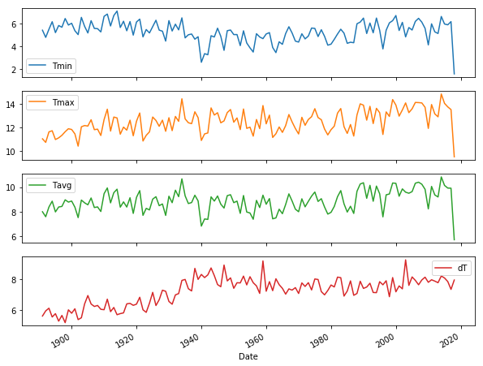

```python
df_annual_means.plot(subplots=True, figsize=(10,8));
```

### Plotting

Pandas uses Matplotlib to generate figures. Once Pandas has generatued a figure, all of Matplotlib's function can be used ot modify and customize labels, axes, grids, etc.

Using the `.plot` method, many predefined common plotting variantes are accessible, such as `.box()`, `.scatter()`, or `.hist()`. Pandas interprets the data structure and automatically determines the axes.

Example: Box plot of all columns

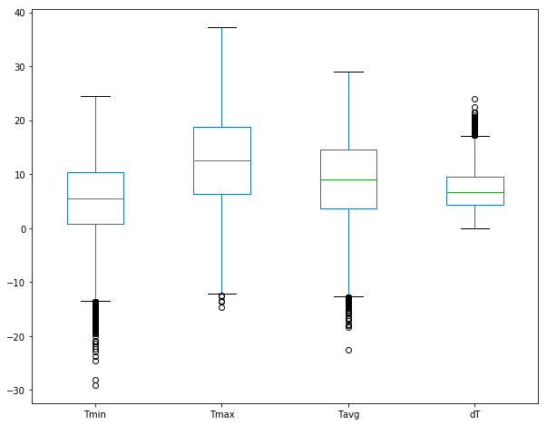

```python
df.plot.box(figsize=(10,8))
```

Example: Scatter plot of Tmin vs. Tmax for the years 2000-2005

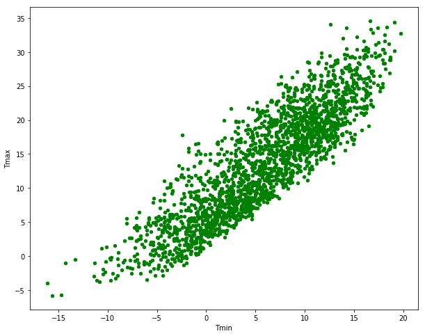

```python
df['2000':'2005'].plot.scatter(x='Tmin',y='Tmax', color='green', figsize=(10,8))
```

Example: Kernel Density Estimate (KDE) plot and some adjustments

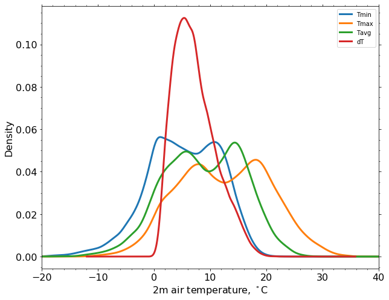

```python
ax = df.plot.density(linewidth=3, figsize=(10,8))

ax.set_xlim([-20, 40])

ax.set_ylabel('Density', fontsize='16')
ax.set_xlabel('2m air temperature, $^\circ$C', fontsize='16')
plt.xticks(fontsize='16')
plt.yticks(fontsize='16')

ax.minorticks_on()
ax.tick_params(axis='y', right='on', left='on', which='both')
ax.tick_params(axis='x', bottom='on', top='on', which='both')
```

### Seaborn - Statistical Visualization

Seaborn is a Python visualization library based on Matplotlib and Pandas. It provides a high-level interface for **drawing attractive statistical graphics**.

```python
# Importing seaborn module
import seaborn as sb
```

Make a simple **linear regression** plot:

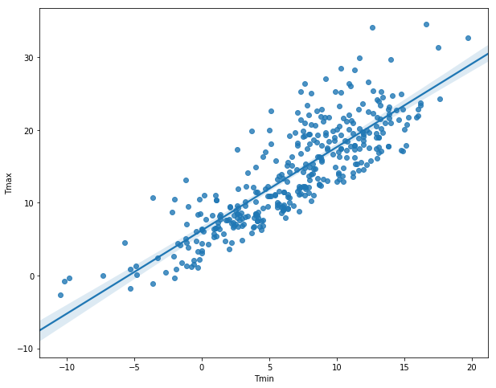

```python
plt.figure(figsize=(10,8))
sb.regplot(x='Tmin', y='Tmax', data=df['2000']);
```

**Violinplot**: Comparison of temperature distributions during an El Niño (1982-83) and La Niña (1988-89) event

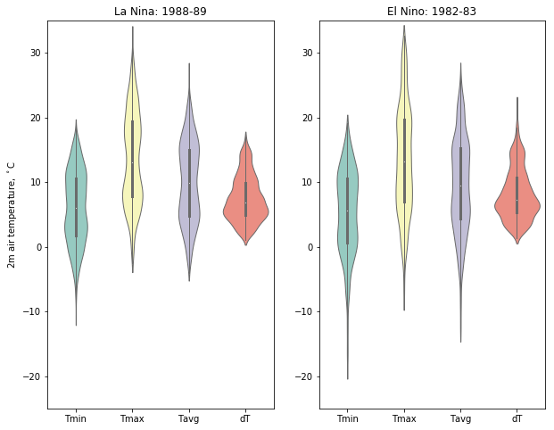

```python
plt.figure(figsize=(10,8))
ax1 = plt.subplot(121)
sb.violinplot(data=df['1988':'1989'], palette="Set3", bw=0.2, cut=1, linewidth=1, ax=ax1)
ax1.set_ylim([-25, 35])
ax1.set_title('La Nina: 1988-89')
ax1.set_ylabel('2m air temperature, $^\circ$C')

ax2 = plt.subplot(122)
sb.violinplot(data=df['1982':'1983'], palette="Set3", bw=0.2, cut=1, linewidth=1, ax=ax2)
ax2.set_ylim([-25, 35])
ax2.set_title('El Nino: 1982-83');
```

Many more examples of appealing statistical visualisations can be found at [Seaborn gallery](http://seaborn.pydata.org/examples/index.html) and [Seaborn Tutorial](http://seaborn.pydata.org/tutorial.html).

### Links

- [Pandas Documentation](http://pandas.pydata.org/pandas-docs/stable/index.html)
- [Pandas Tutorial / Cookbooks](http://pandas.pydata.org/pandas-docs/stable/tutorials.html)
- [Seaborn](http://seaborn.pydata.org/index.html)

See also attached Cheatsheets.

#### This short introduction does not cover:

- Reshaping (Stack / Unstack, Pivot Tables)
- Panel objects
- MultiIndexing
- Itertools
- Categorical Data
- ... Pandas is a huge package - there is a lot to explore!

Please read the documentation for more details.

### Excerises

**Time Series Analysis of Fuhlsbüttel record, Hamburg:**

1. Read in `dwdstation_hamburg_fuhlsbuettel_kl_10147.csv` by means of pandas’ `.read_csv` function in a DataFrame (air temperature, column 15) object.
2. Calculate monthly means for the entire period and a climatology for the month January to December.
3. Use the curve_fit function from scipy.optimize to create a fit for the climatology based on a sine function. Plot the first guess, the climatology and the best fit in one figure.
4. Calculate monthly anomalies using the climatology and compute the trend (by means of the function scipy.linregress) from these anomalies. Plot the monthly means and the trend in one figure.

File path: `/data/icdc/atmosphere/dwd_stations/DATA/dwdstation_hamburg_fuhlsbuettel_kl_10147.csv`

Name of program file: pandas_analysis.py